# MovieLensProjectSolution

### Project - MovieLens Data Analysis

The GroupLens Research Project is a research group in the Department of Computer Science and Engineering at the University of Minnesota. The data is widely used for collaborative filtering and other filtering solutions. However, we will be using this data to act as a means to demonstrate our skill in using Python to “play” with data.

#### Domain

Internet and Entertainment

**Note that the project will need you to apply the concepts of groupby and merging extensively.**

git: https://github.com/GreatLearningAIML1/gl-pgp-aiml-uta-intl-may20-bunty-sunbird/tree/master/project/MovieLensDataExploration

```python
import warnings
warnings.filterwarnings('ignore')
```

#### 1. Import the necessary packages - 2.5 marks

```python
import numpy as np
import pandas as pd
import seaborn as sns
import matplotlib.pyplot as plt
from scipy import stats

%matplotlib inline

sns.set(color_codes=True)

from IPython.display import display, HTML
```

#### 2. Read the 3 datasets into dataframes - 2.5 marks

```python
userrating = pd.read_csv('Data.csv')

moviegenre = pd.read_csv('item.csv')

user = pd.read_csv('user.csv')
```

```python
userrating.head()
```

|  | user id | movie id | rating | timestamp |
| --- | --- | --- | --- | --- |
| 0 | 196 | 242 | 3 | 881250949 |
| 1 | 186 | 302 | 3 | 891717742 |
| 2 | 22 | 377 | 1 | 878887116 |
| 3 | 244 | 51 | 2 | 880606923 |
| 4 | 166 | 346 | 1 | 886397596 |

```python
moviegenre.head()
```

|  | movie id | movie title | release date | unknown | Action | Adventure | Animation | Childrens | Comedy | Crime | ... | Fantasy | Film-Noir | Horror | Musical | Mystery | Romance | Sci-Fi | Thriller | War | Western |
| --- | --- | --- | --- | --- | --- | --- | --- | --- | --- | --- | --- | --- | --- | --- | --- | --- | --- | --- | --- | --- | --- |
| 0 | 1 | Toy Story | 01-Jan-1995 | 0 | 0 | 0 | 1 | 1 | 1 | 0 | ... | 0 | 0 | 0 | 0 | 0 | 0 | 0 | 0 | 0 | 0 |
| 1 | 2 | GoldenEye | 01-Jan-1995 | 0 | 1 | 1 | 0 | 0 | 0 | 0 | ... | 0 | 0 | 0 | 0 | 0 | 0 | 0 | 1 | 0 | 0 |
| 2 | 3 | Four Rooms | 01-Jan-1995 | 0 | 0 | 0 | 0 | 0 | 0 | 0 | ... | 0 | 0 | 0 | 0 | 0 | 0 | 0 | 1 | 0 | 0 |
| 3 | 4 | Get Shorty | 01-Jan-1995 | 0 | 1 | 0 | 0 | 0 | 1 | 0 | ... | 0 | 0 | 0 | 0 | 0 | 0 | 0 | 0 | 0 | 0 |
| 4 | 5 | Copycat | 01-Jan-1995 | 0 | 0 | 0 | 0 | 0 | 0 | 1 | ... | 0 | 0 | 0 | 0 | 0 | 0 | 0 | 1 | 0 | 0 |

5 rows × 22 columns

```python
user.head()
```

|  | user id | age | gender | occupation | zip code |
| --- | --- | --- | --- | --- | --- |
| 0 | 1 | 24 | M | technician | 85711 |
| 1 | 2 | 53 | F | other | 94043 |
| 2 | 3 | 23 | M | writer | 32067 |
| 3 | 4 | 24 | M | technician | 43537 |
| 4 | 5 | 33 | F | other | 15213 |

#### 3. Apply info, shape, describe, and find the number of missing values in the data - 5 marks

```python
def missing_data(df):
    if df.isnull().any().any():
        print('have missing data')
        print('total missing data: ', df.isnull().sum().sum())
        print('missing data per col: ', df.isnull().sum())
    else:
        print('\nNo missing data\n')

def df_info(df):
    print('Info')
    print('=============')
    print (df.info())

    print('')
    print ('shape:\n ========== \n', df.shape)

    display ('==== describe: ====', df.describe().transpose().round())

    print ('Missing data info')
    print ('==================')
    # print ('any missing data: \n', missing_data(df)) # df.isnull().sum())
    missing_data(df)

    display('top few rows: ', df.head())
```

```python
df_info(userrating)
```

```
Info
=============
<class 'pandas.core.frame.DataFrame'>
RangeIndex: 100000 entries, 0 to 99999
Data columns (total 4 columns):
 #   Column     Non-Null Count   Dtype
---  ------     --------------   -----
 0   user id    100000 non-null  int64
 1   movie id   100000 non-null  int64
 2   rating     100000 non-null  int64
 3   timestamp  100000 non-null  int64
dtypes: int64(4)
memory usage: 3.1 MB
None

shape:
 ==========
 (100000, 4)
```

```
'==== describe: ===='
```

|  | count | mean | std | min | 25% | 50% | 75% | max |
| --- | --- | --- | --- | --- | --- | --- | --- | --- |
| user id | 100000.0 | 462.0 | 267.0 | 1.0 | 254.0 | 447.0 | 682.0 | 943.0 |
| movie id | 100000.0 | 426.0 | 331.0 | 1.0 | 175.0 | 322.0 | 631.0 | 1682.0 |
| rating | 100000.0 | 4.0 | 1.0 | 1.0 | 3.0 | 4.0 | 4.0 | 5.0 |
| timestamp | 100000.0 | 883528851.0 | 5343856.0 | 874724710.0 | 879448710.0 | 882826944.0 | 888259984.0 | 893286638.0 |

```
Missing data info
==================

No missing data
```

```
'top few rows: '
```

|  | user id | movie id | rating | timestamp |
| --- | --- | --- | --- | --- |
| 0 | 196 | 242 | 3 | 881250949 |
| 1 | 186 | 302 | 3 | 891717742 |
| 2 | 22 | 377 | 1 | 878887116 |
| 3 | 244 | 51 | 2 | 880606923 |
| 4 | 166 | 346 | 1 | 886397596 |

```python
df_info(moviegenre)
```

```
Info
=============
<class 'pandas.core.frame.DataFrame'>
RangeIndex: 1681 entries, 0 to 1680
Data columns (total 22 columns):
 #   Column        Non-Null Count  Dtype
---  ------        --------------  -----
 0   movie id      1681 non-null   int64
 1   movie title   1681 non-null   object
 2   release date  1681 non-null   object
 3   unknown       1681 non-null   int64
 4   Action        1681 non-null   int64
 5   Adventure     1681 non-null   int64
 6   Animation     1681 non-null   int64
 7   Childrens     1681 non-null   int64
 8   Comedy        1681 non-null   int64
 9   Crime         1681 non-null   int64
 10  Documentary   1681 non-null   int64
 11  Drama         1681 non-null   int64
 12  Fantasy       1681 non-null   int64
 13  Film-Noir     1681 non-null   int64
 14  Horror        1681 non-null   int64
 15  Musical       1681 non-null   int64
 16  Mystery       1681 non-null   int64
 17  Romance       1681 non-null   int64
 18  Sci-Fi        1681 non-null   int64
 19  Thriller      1681 non-null   int64
 20  War           1681 non-null   int64
 21  Western       1681 non-null   int64
dtypes: int64(20), object(2)
memory usage: 289.0+ KB
None

shape:
 ==========
 (1681, 22)
```

```
'==== describe: ===='
```

|  | count | mean | std | min | 25% | 50% | 75% | max |
| --- | --- | --- | --- | --- | --- | --- | --- | --- |
| movie id | 1681.0 | 842.0 | 486.0 | 1.0 | 422.0 | 842.0 | 1262.0 | 1682.0 |
| unknown | 1681.0 | 0.0 | 0.0 | 0.0 | 0.0 | 0.0 | 0.0 | 1.0 |
| Action | 1681.0 | 0.0 | 0.0 | 0.0 | 0.0 | 0.0 | 0.0 | 1.0 |
| Adventure | 1681.0 | 0.0 | 0.0 | 0.0 | 0.0 | 0.0 | 0.0 | 1.0 |
| Animation | 1681.0 | 0.0 | 0.0 | 0.0 | 0.0 | 0.0 | 0.0 | 1.0 |
| Childrens | 1681.0 | 0.0 | 0.0 | 0.0 | 0.0 | 0.0 | 0.0 | 1.0 |
| Comedy | 1681.0 | 0.0 | 0.0 | 0.0 | 0.0 | 0.0 | 1.0 | 1.0 |
| Crime | 1681.0 | 0.0 | 0.0 | 0.0 | 0.0 | 0.0 | 0.0 | 1.0 |
| Documentary | 1681.0 | 0.0 | 0.0 | 0.0 | 0.0 | 0.0 | 0.0 | 1.0 |
| Drama | 1681.0 | 0.0 | 0.0 | 0.0 | 0.0 | 0.0 | 1.0 | 1.0 |
| Fantasy | 1681.0 | 0.0 | 0.0 | 0.0 | 0.0 | 0.0 | 0.0 | 1.0 |
| Film-Noir | 1681.0 | 0.0 | 0.0 | 0.0 | 0.0 | 0.0 | 0.0 | 1.0 |
| Horror | 1681.0 | 0.0 | 0.0 | 0.0 | 0.0 | 0.0 | 0.0 | 1.0 |
| Musical | 1681.0 | 0.0 | 0.0 | 0.0 | 0.0 | 0.0 | 0.0 | 1.0 |
| Mystery | 1681.0 | 0.0 | 0.0 | 0.0 | 0.0 | 0.0 | 0.0 | 1.0 |
| Romance | 1681.0 | 0.0 | 0.0 | 0.0 | 0.0 | 0.0 | 0.0 | 1.0 |
| Sci-Fi | 1681.0 | 0.0 | 0.0 | 0.0 | 0.0 | 0.0 | 0.0 | 1.0 |
| Thriller | 1681.0 | 0.0 | 0.0 | 0.0 | 0.0 | 0.0 | 0.0 | 1.0 |
| War | 1681.0 | 0.0 | 0.0 | 0.0 | 0.0 | 0.0 | 0.0 | 1.0 |
| Western | 1681.0 | 0.0 | 0.0 | 0.0 | 0.0 | 0.0 | 0.0 | 1.0 |

```
Missing data info
==================

No missing data
```

```
'top few rows: '
```

|  | movie id | movie title | release date | unknown | Action | Adventure | Animation | Childrens | Comedy | Crime | ... | Fantasy | Film-Noir | Horror | Musical | Mystery | Romance | Sci-Fi | Thriller | War | Western |
| --- | --- | --- | --- | --- | --- | --- | --- | --- | --- | --- | --- | --- | --- | --- | --- | --- | --- | --- | --- | --- | --- |
| 0 | 1 | Toy Story | 01-Jan-1995 | 0 | 0 | 0 | 1 | 1 | 1 | 0 | ... | 0 | 0 | 0 | 0 | 0 | 0 | 0 | 0 | 0 | 0 |
| 1 | 2 | GoldenEye | 01-Jan-1995 | 0 | 1 | 1 | 0 | 0 | 0 | 0 | ... | 0 | 0 | 0 | 0 | 0 | 0 | 0 | 1 | 0 | 0 |
| 2 | 3 | Four Rooms | 01-Jan-1995 | 0 | 0 | 0 | 0 | 0 | 0 | 0 | ... | 0 | 0 | 0 | 0 | 0 | 0 | 0 | 1 | 0 | 0 |
| 3 | 4 | Get Shorty | 01-Jan-1995 | 0 | 1 | 0 | 0 | 0 | 1 | 0 | ... | 0 | 0 | 0 | 0 | 0 | 0 | 0 | 0 | 0 | 0 |
| 4 | 5 | Copycat | 01-Jan-1995 | 0 | 0 | 0 | 0 | 0 | 0 | 1 | ... | 0 | 0 | 0 | 0 | 0 | 0 | 0 | 1 | 0 | 0 |

5 rows × 22 columns

```python
df_info(user)
```

```
Info
=============
<class 'pandas.core.frame.DataFrame'>
RangeIndex: 943 entries, 0 to 942
Data columns (total 5 columns):
 #   Column      Non-Null Count  Dtype
---  ------      --------------  -----
 0   user id     943 non-null    int64
 1   age         943 non-null    int64
 2   gender      943 non-null    object
 3   occupation  943 non-null    object
 4   zip code    943 non-null    object
dtypes: int64(2), object(3)
memory usage: 37.0+ KB
None

shape:
 ==========
 (943, 5)
```

```
'==== describe: ===='
```

|  | count | mean | std | min | 25% | 50% | 75% | max |
| --- | --- | --- | --- | --- | --- | --- | --- | --- |
| user id | 943.0 | 472.0 | 272.0 | 1.0 | 236.0 | 472.0 | 708.0 | 943.0 |
| age | 943.0 | 34.0 | 12.0 | 7.0 | 25.0 | 31.0 | 43.0 | 73.0 |

```
Missing data info
==================

No missing data
```

```
'top few rows: '
```

|  | user id | age | gender | occupation | zip code |
| --- | --- | --- | --- | --- | --- |
| 0 | 1 | 24 | M | technician | 85711 |
| 1 | 2 | 53 | F | other | 94043 |
| 2 | 3 | 23 | M | writer | 32067 |
| 3 | 4 | 24 | M | technician | 43537 |
| 4 | 5 | 33 | F | other | 15213 |

#### 4. Find the number of movies per genre using the item data - 5 marks

```python
# use sum on the default axis
moviegenre_sum = moviegenre.sum(axis = 0, numeric_only=True).reset_index()
moviegenre_sum.columns = ['Movie Genre', 'Number of Movies']
moviegenre_sum[moviegenre_sum['Movie Genre'] != 'movie id']
```

|  | Movie Genre | Number of Movies |
| --- | --- | --- |
| 1 | unknown | 1 |
| 2 | Action | 251 |
| 3 | Adventure | 135 |
| 4 | Animation | 42 |
| 5 | Childrens | 122 |
| 6 | Comedy | 505 |
| 7 | Crime | 109 |
| 8 | Documentary | 50 |
| 9 | Drama | 725 |
| 10 | Fantasy | 22 |
| 11 | Film-Noir | 24 |
| 12 | Horror | 92 |
| 13 | Musical | 56 |
| 14 | Mystery | 61 |
| 15 | Romance | 247 |
| 16 | Sci-Fi | 101 |
| 17 | Thriller | 251 |
| 18 | War | 71 |
| 19 | Western | 27 |

#### 5. Find the movies that have more than one genre - 2.5 marks

```python
moviegenre_count = moviegenre.copy()

moviegenre_count['genre_count'] = moviegenre.sum(axis=1, numeric_only=True) - moviegenre['movie id']

moviegenre_count[(moviegenre_count['genre_count'] > 1)][['movie title', 'genre_count']]
```

|  | movie title | genre_count |
| --- | --- | --- |
| 0 | Toy Story | 3 |
| 1 | GoldenEye | 3 |
| 3 | Get Shorty | 3 |
| 4 | Copycat | 3 |
| 6 | Twelve Monkeys | 2 |
| ... | ... | ... |
| 1667 | MURDER and murder | 3 |
| 1668 | Tainted | 2 |
| 1671 | Mirage | 2 |
| 1677 | B. Monkey | 2 |
| 1678 | Sliding Doors | 2 |

849 rows × 2 columns

#### 6. Drop the movie where the genre is unknown - 2.5 marks

```python
moviegenre.drop(moviegenre[moviegenre.unknown == 1].index, inplace=True)

moviegenre[(moviegenre.unknown == 1)]
```

|  | movie id | movie title | release date | unknown | Action | Adventure | Animation | Childrens | Comedy | Crime | ... | Fantasy | Film-Noir | Horror | Musical | Mystery | Romance | Sci-Fi | Thriller | War | Western |
| --- | --- | --- | --- | --- | --- | --- | --- | --- | --- | --- | --- | --- | --- | --- | --- | --- | --- | --- | --- | --- | --- |

0 rows × 22 columns

### 7. Univariate plots of columns: 'rating', 'Age', 'release year', 'Gender' and 'Occupation' - 10 marks

```python
# HINT: use distplot for age and countplot for gender,ratings,occupation.
# HINT: Please refer to the below snippet to understand how to get to release year from release date. You can use str.split()
# as depicted below
# Hint : Use displot without kde for release year or line plot showing year wise count.
```

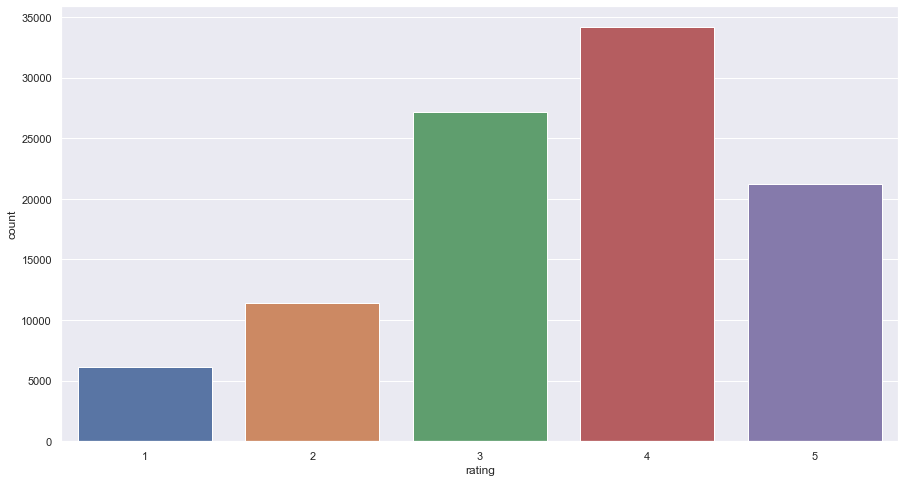

```python
#your answers here
# Rating count plot

plt.figure(figsize=(15,8))

sns.countplot('rating', data=userrating, palette='deep');
```

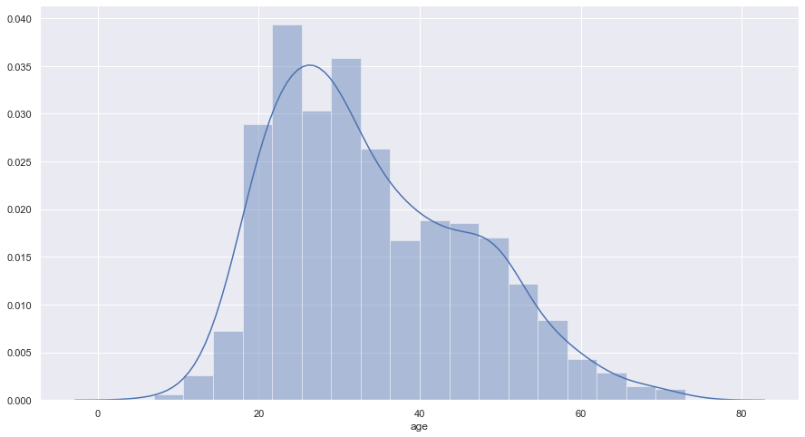

```python
# Age distribution plot

plt.figure(figsize=(15,8))
sns.distplot(user.age, kde=True);
```

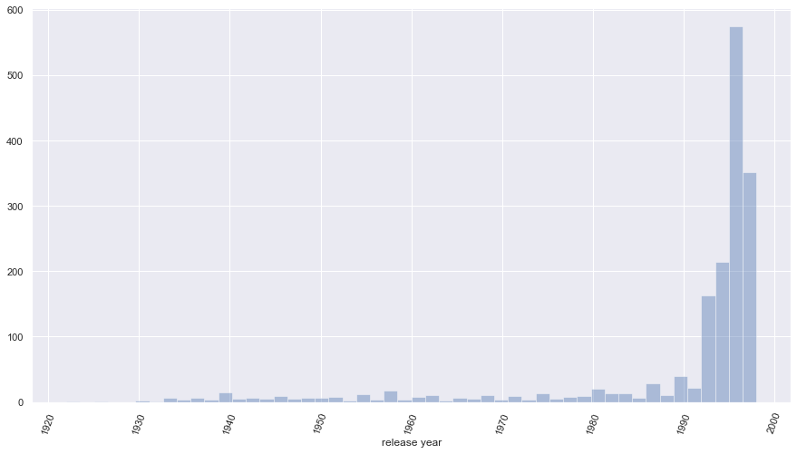

```python
# Release year dist chart

def year(text):
    return text.split('-')[2]

plt.figure(figsize=(15,8))
plt.xticks(rotation=70)

# sns.distplot(yearData);

sns.distplot(moviegenre['release date'].apply(year).apply(int).rename('release year'), kde=False);
```

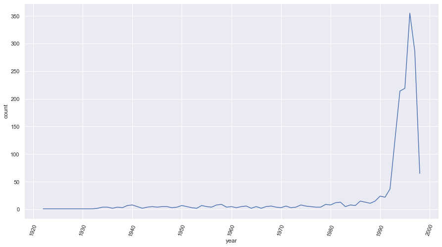

```python
# Release year line plot

plt.figure(figsize=(15,8))
plt.xticks(rotation=70)

#
# get the series with the year
#
yearData = moviegenre['release date'].apply(year).apply(int)
# yearData.describe()

#
# convert series to the Data Frame with 'year' and 'count'
#
yearData = yearData.value_counts().reset_index().rename(columns={'index': 'year', 'release date': 'count'})
yearData

#
# plot number of movies per year
#
sns.lineplot(data=yearData, x='year', y='count');
```

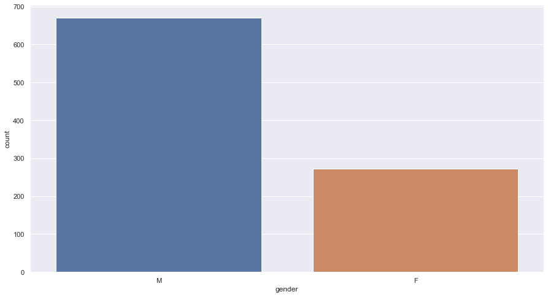

```python
# Gender count chart

plt.figure(figsize=(15,8))

sns.countplot('gender', data=user);
```

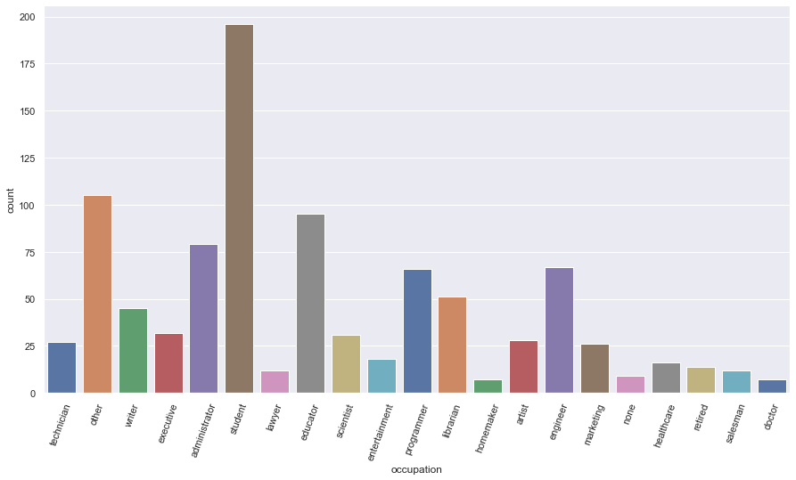

```python
# Occupation count chart

plt.figure(figsize=(15,8))
plt.xticks(rotation=70)

sns.countplot('occupation', data=user, palette='deep');
```

### 8. Visualize how popularity of genres has changed over the years - 10 marks

Note that you need to use the number of releases in a year as a parameter of popularity of a genre

Hint

1: you need to reach to a data frame where the release year is the index and the genre is the column names (one cell shows the number of release in a year in one genre) or vice versa. Once that is achieved, you can either use univariate plots or can use the heatmap to visualise all the changes over the years in one go.

Hint 2: Use groupby on the relevant column and use sum() on the same to find out the nuumber of releases in a year/genre.

```python
#Your answer here

#
# add a new column 'year' in a copied data frame, to plot the genre popularities over the years
#

genre_columns = ['unknown', 'Action',
       'Adventure', 'Animation', 'Childrens', 'Comedy', 'Crime', 'Documentary',
       'Drama', 'Fantasy', 'Film-Noir', 'Horror', 'Musical', 'Mystery',
       'Romance', 'Sci-Fi', 'Thriller', 'War', 'Western']

moviegenre_year = moviegenre.copy()

moviegenre_year['year'] = moviegenre['release date'].apply(year).apply(int)

genre_columns.append('year')

grp = moviegenre_year[genre_columns].groupby('year')

genre_per_year = grp.sum()
```

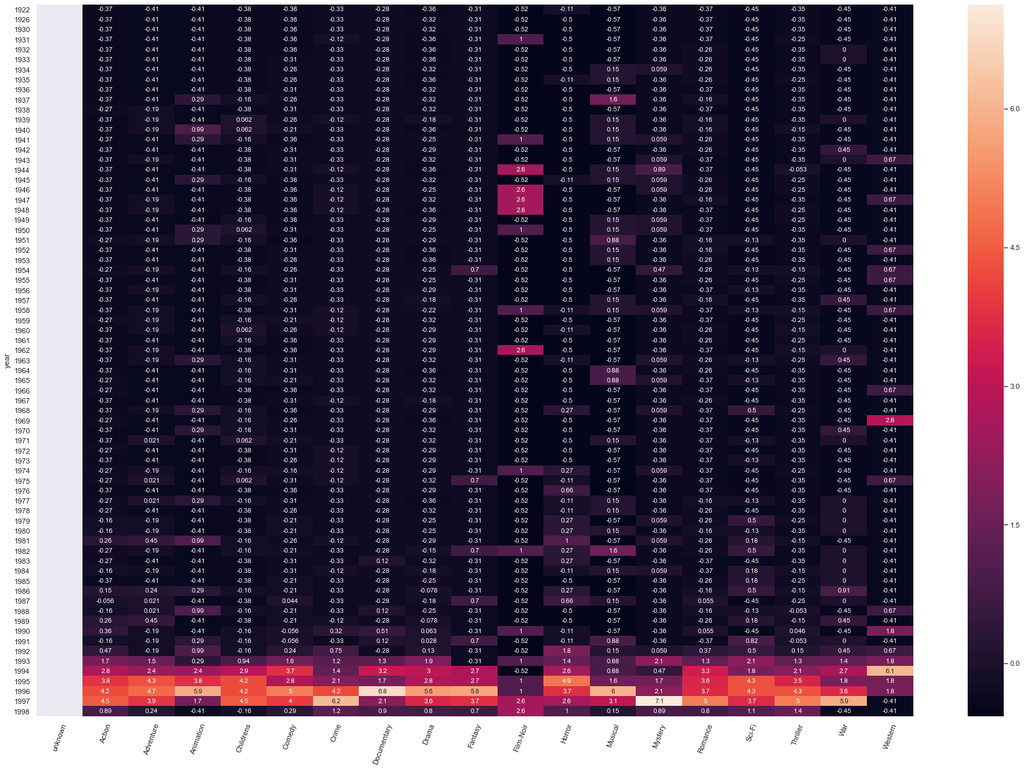

```python
#
# get the normalized (using zscore) heat map comparing genres popularities over the years
#

plt.figure(figsize=(30,20))
plt.xticks(rotation=70)

sns.heatmap(genre_per_year.apply(stats.zscore), annot=True);
```

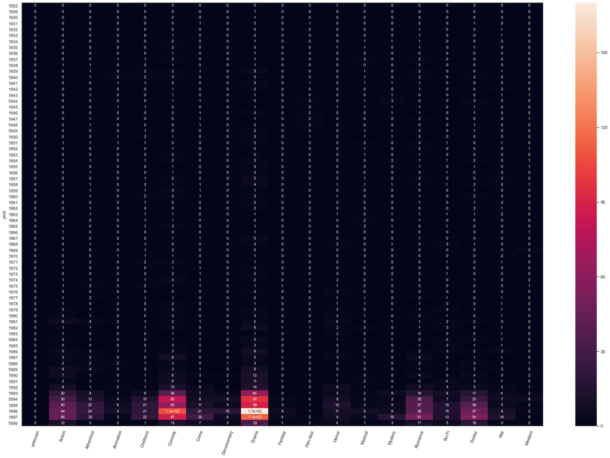

```python
#
# get the heat map comparing genres popularities over the years
#

plt.figure(figsize=(30,20))
plt.xticks(rotation=70)

sns.heatmap(genre_per_year, annot=True, vmin=0);
```

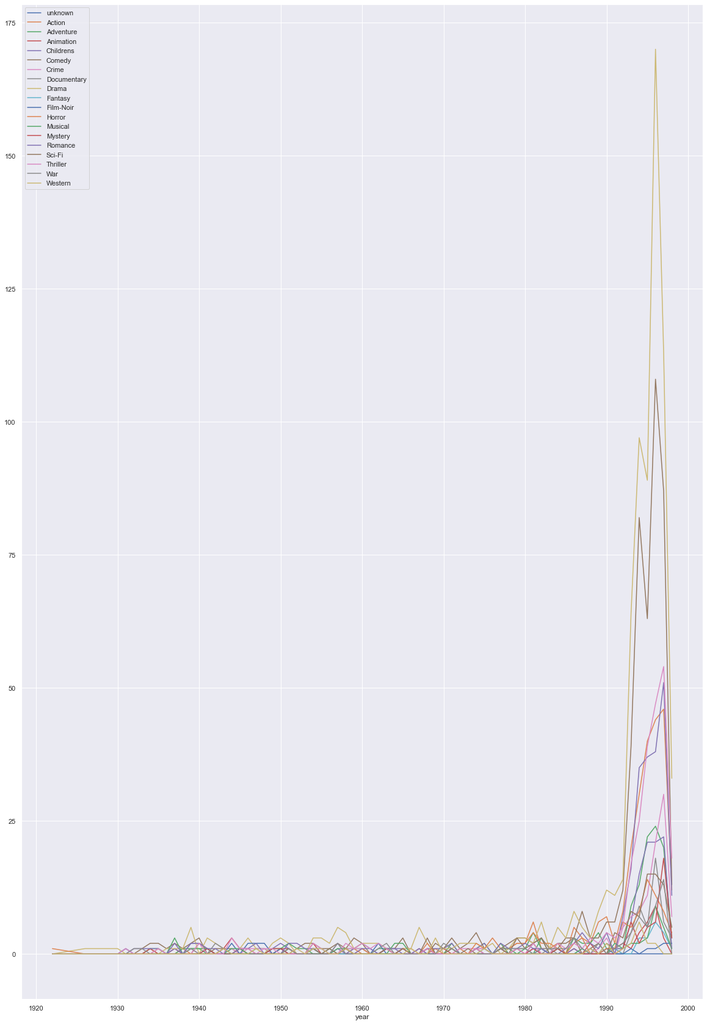

```python
#
# line chart comparing all the movie genre watch count over the years
#

genre_per_year.plot(figsize=(20,30));
```

### 9. Find the top 25 movies according to average ratings such that each movie has number of ratings more than 100 - 10 marks

Hint :

1. First find the movies that have more than 100 ratings(use merge, groupby and count). Extract the movie titles in a list.
2. Find the average rating of all the movies and sort them in the descending order. You will have to use the .merge() function to reach to a data set through which you can get the names and the average rating.
3. Use isin(list obtained from 1) to filter out the movies which have more than 100 ratings.

Note: This question will need you to research about groupby and apply your findings. You can find more on groupby on https://realpython.com/pandas-groupby/.

```python
#your answer here
#
# find all movies that have more than 100 ratings
#
movie_rating = pd.merge(moviegenre, userrating, how='inner', on='movie id').groupby(['movie id', 'movie title'])['rating'].count().reset_index()
movie_rating100plus = movie_rating[movie_rating.rating > 100]

#
# sort movies with highest average rating first
#
movie_toprated = pd.merge(moviegenre, userrating, how='inner', on='movie id').groupby(['movie id', 'movie title'])['rating'].mean().sort_values(ascending=False).reset_index()

#
# from the top rated movies filter those that have more than 100 ratings
#
topAndMoreRated = movie_toprated[(movie_toprated['movie title'].isin(movie_rating100plus['movie title']))]

# display the top 25 movies and its rating
topAndMoreRated.head(25)
```

|  | movie id | movie title | rating |
| --- | --- | --- | --- |
| 15 | 408 | Close Shave, A | 4.491071 |
| 16 | 318 | Schindler's List | 4.466443 |
| 17 | 169 | Wrong Trousers, The | 4.466102 |
| 18 | 483 | Casablanca | 4.456790 |
| 20 | 64 | Shawshank Redemption, The | 4.445230 |
| 21 | 603 | Rear Window | 4.387560 |
| 22 | 12 | Usual Suspects, The | 4.385768 |
| 23 | 50 | Star Wars | 4.358491 |
| 24 | 178 | 12 Angry Men | 4.344000 |
| 28 | 134 | Citizen Kane | 4.292929 |
| 30 | 427 | To Kill a Mockingbird | 4.292237 |
| 31 | 357 | One Flew Over the Cuckoo's Nest | 4.291667 |
| 32 | 98 | Silence of the Lambs, The | 4.289744 |
| 33 | 480 | North by Northwest | 4.284916 |
| 34 | 127 | Godfather, The | 4.283293 |
| 35 | 285 | Secrets & Lies | 4.265432 |
| 36 | 272 | Good Will Hunting | 4.262626 |
| 38 | 657 | Manchurian Candidate, The | 4.259542 |
| 39 | 474 | Dr. Strangelove or: How I Learned to Stop Worr... | 4.252577 |
| 40 | 174 | Raiders of the Lost Ark | 4.252381 |
| 41 | 479 | Vertigo | 4.251397 |
| 45 | 313 | Titanic | 4.245714 |
| 46 | 511 | Lawrence of Arabia | 4.231214 |
| 48 | 484 | Maltese Falcon, The | 4.210145 |
| 49 | 172 | Empire Strikes Back, The | 4.204360 |

### 10. See gender distribution across different genres check for the validity of the below statements - 10 marks

- Men watch more drama than women
- Women watch more Sci-Fi than men
- Men watch more Romance than women
1. There is no need to conduct statistical tests around this. Just compare the percentages and comment on the validity of the above statements.
2. you might want ot use the .sum(), .div() function here.
3. Use number of ratings to validate the numbers. For example, if out of 4000 ratings received by women, 3000 are for drama, we will assume that 75% of the women watch drama.

#### Conclusion:

- Men watch more drama than women: False
- Women watch more Sci-Fi than men: False
- Men watch more Romance than women: False

```python
#
# merge all tables
#
movie_userrating = pd.merge(moviegenre, userrating, how='inner', on='movie id')

movie_user = pd.merge(movie_userrating, user, how='inner', on='user id')

#
# get rating count per gender
#
male_total_count = movie_user[(movie_user['gender'] == 'M')].count()['movie id']
female_total_count = movie_user[(movie_user['gender'] == 'F')].count()['movie id']


#
# calculate the percent of male and female percent rating for a given genre
#
def percent_genre(genre):
    mur = movie_user.groupby(['gender', genre]).count()

    female_count = mur.loc[('F', 1)]['movie id']
    male_count = mur.loc[('M', 1)]['movie id']
    total = female_count + male_count

    return (female_count / female_total_count * 100, male_count / male_total_count * 100)

#
# declare the result of men v/s female watch percent for a given genre
#
def result(genre):
    val = percent_genre(genre)
    print('Female watch % (', val[0], ')', genre, 'more' if (val[0] > val[1]) else 'less', 'then men % (', val[1], ')')

result('Drama')

result('Sci-Fi')

result('Romance')
```

```
Female watch % ( 42.76944595539669 ) Drama more then men % ( 38.90400258578893 )
Female watch % ( 10.214468878700753 ) Sci-Fi less then men % ( 13.603673975111782 )
Female watch % ( 22.760121221540135 ) Romance more then men % ( 18.320045251306365 )
```